# RareQ for RNA & ADT Multiome Data

Last edited: November 16, 2025

**RareQ** operates on any Seurat object with a neighborhood graph and can integrate multimodal data. This tutorial demonstrates how to identify rare cell populations in **CITE-seq data** using RareQ, within Seurat’s multimodal analysis framework.

The example dataset (`bmcite`) contains paired RNA and ADT profiles from human bone marrow mononuclear cells. The data and preprocessing steps can be found at https://satijalab.org/seurat/articles/weighted_nearest_neighbor_analysis.

## Load the data

```r
library(Seurat)
library(RareQ)   # core method for rare-cell detection
library(dplyr)
library(ggplot2)

# Read example data
# Please replace the path with your local "Tutorial_example" directory
bm = readRDS('Tutorial_example/data/bmcite.RDS')
```

## Preprocess RNA and ADT modalities separately

Each modality is normalized and dimensionally reduced independently. RNA features capture transcriptional programs, while ADT features reflect surface protein abundance.

```r
Assays(bm)
```

```
## [1] "RNA" "ADT"
```

```r
# RNA processing
DefaultAssay(bm) <- 'RNA'
bm <- NormalizeData(bm) %>% FindVariableFeatures() %>% ScaleData() %>% RunPCA()

# ADT processing
DefaultAssay(bm) <- 'ADT'
VariableFeatures(bm) <- rownames(bm[["ADT"]])           # use all ADT features for dimensional reduction
bm <- NormalizeData(bm, normalization.method = 'CLR', margin = 2) %>%
  ScaleData() %>%
  RunPCA(reduction.name = 'apca')       # run PCA for ADT modality
```

## Integrate modalities with WNN

The **Weighted Nearest Neighbor (WNN)** is an unsupervised framework for combining multiple modalities measured within the same cell. It assigns cell-specific weights to each modality according to its relative information content and generated a unified low-dimensional embedding that retains modality-specific signals. Here, we use WNN to integrate RNA and protein modalities in CITE-seq data. Note that it can also be applied to joint analysis of scRNA-seq and scATAC-seq data.

```r
bm <- FindMultiModalNeighbors(
  bm,
  reduction.list = list("pca", "apca"),          # use PCA results from RNA and ADT
  dims.list = list(1:30, 1:18),                  # specify number of PCs per modality
  modality.weight.name = "RNA.weight"
  )
```

```r
# Run UMAP based on the integrated WNN graph
bm <- RunUMAP(bm, nn.name = "weighted.nn",
              reduction.name = "wnn.umap", reduction.key ="wnnUMAP_")
```

## Build the kNN graph

RareQ requires a structure-preserving embedding in which local distances reflect multimodal cell relationships. We obtain this by applying supervised PCA (sPCA) based on the WNN graph: sPCA learns a linear projection of a single modality (here RNA) whose principal components reproduce the neighbor topology defined by the multimodal WNN graph.

```r
DefaultAssay(bm) = 'RNA'

# Compute sPCA embedding guided by the WNN graph
bm <- RunSPCA(bm, assay = 'RNA', graph = 'wsnn')
```

Then, compute cell neighborhoods. The `k.param` (default 20) nearest neighbors for each cell were determined based on Euclidean distances in the low-dimensional sPCA space.

```r
# These will serve as the input graph for RareQ
bm <- FindNeighbors(object = bm,
                    k.param = 20,
                    compute.SNN = FALSE,       # RareQ relies on directed kNN, not SNN
                    prune.SNN = 0,
                    reduction = "spca",
                    dims = 1:50,
                    force.recalc = FALSE,
                    return.neighbor = TRUE)    # returned neighbor list is essential for Q propagation
```

## Run RareQ

Now we use `RareQ::FindRare()` to derive both major and rare cell clusters, and attach the identified cluster labels to Seurat metadata.

```r
cluster = FindRare(sc_object = bm)
table(cluster)
```

```
## cluster
##    12   267   684   885  1035  1094  1620  2207  2468  3361  3991  5432  5800
##   431   328     8    36    11   106    59   257    32    44  9776   218    20
##  5962  7588  7767  8267  8315  8648  9694  9903 10753 11227 12456 12951 14331
##   122   411   258    93    63    63  1411   133    27   507  2105  1323    97
## 14399 15196 15331 15815 16454 16991 17242 17251 19921 21930 22152 24065 24218
##   129    46   315   120    25   515  6958   528    51    29    45   519    57
## 25007 29474
##   205  3191
```

```r
bm$cluster = cluster
```

## Visualization

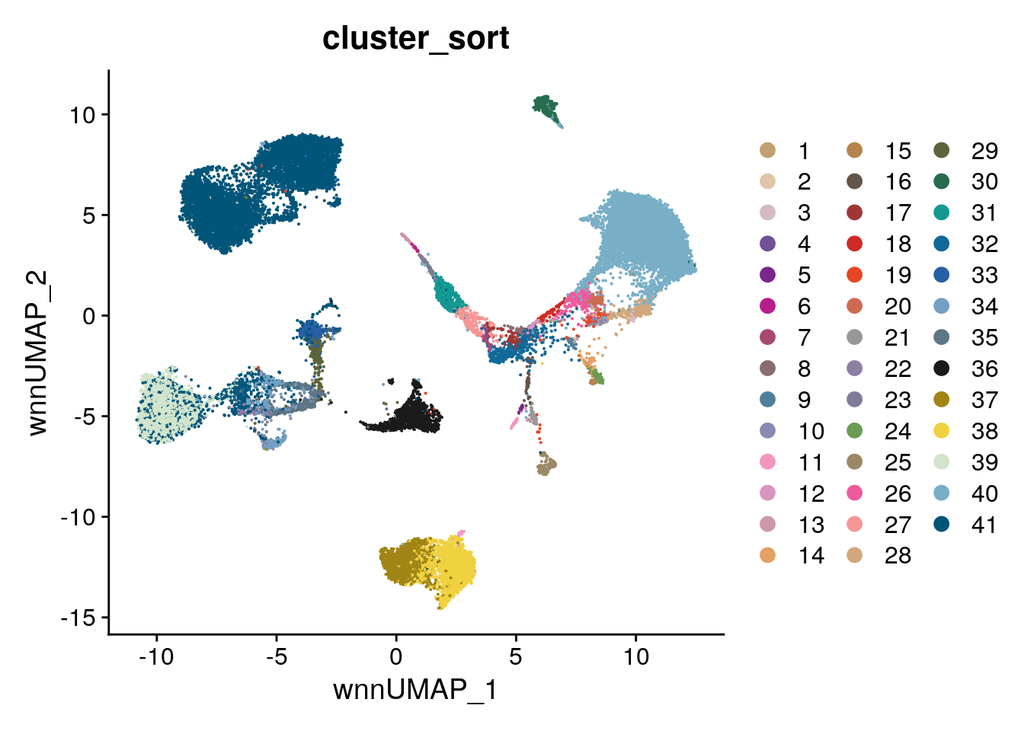

```r
# Label cluster according to cluster size
cluster.cnt <- sort(table(bm$cluster))
bm$cluster_sort = factor(as.character(bm$cluster), levels=names(cluster.cnt),
                         labels = 1:length(cluster.cnt), ordered = T)

# Define color palette for visualization
cols <- c("#532C8A","#c19f70","#f9decf","#c9a997","#B51D8D","#9e6762","#3F84AA","#F397C0",
          "#C594BF","#DFCDE4","#eda450","#635547","#C72228","#EF4E22","#f77b59","#989898",
          "#7F6874","#8870ad","#65A83E","#EF5A9D","#647a4f","#FBBE92","#354E23","#139992",
          "#C3C388","#8EC792","#0F4A9C","#8DB5CE","#1A1A1A","#FACB12","#C9EBFB","#DABE99",
          "#ed8f84","#005579","#CDE088","#BBDCA8","#F6BFCB"
)

getPalette = colorRampPalette(cols[c(2,3,1,5,6,7,8,9,11,12,13,14,16,18,19,20,22,23,24,27,28,29,30,31,34)])

# UMAP visualization of RareQ-identified clusters based on WNN embedding
DimPlot(bm, group.by='cluster_sort', reduction = 'wnn.umap') +
  scale_color_manual(values = getPalette(length(unique(bm$cluster_sort))))
```